# Project 2

Alfred Zhu azz82

# Predicting Ambient Air Pollution

## Title and Introduction

The main goal of this project is to create a model that can predict the average PM2.5 concentration. Monitoring the PM2.5 concentration can be expensive and as a result, monitors tend to be placed in major cities so being able to predict the air quality in areas without those monitors can be beneficial for public health. I will test three different prediction models: linear regression, k-nearest neighbor, and random forest. I will choose the best model using the root mean-squared-error (RMSE) metric.

```r
# Sets up needed packages and data
library(tidyverse)
library(tidymodels)
library(parsnip)

dat0 <- read_csv("https://github.com/rdpeng/stat322E_public/raw/main/data/pm25_data.csv.gz")
```

I am going to select these variables as the predictors for PM2.5 concentration and will be using them for all models to make things more simple.

CMAQ: It is a candidate for replacing ground-based monitors using satellite observations

AOD: Same as CMAQ

zcta_pop: The population in the zip-code area could affect the air quality. Conventional thinking says a bigger population would generally result in more pollution.

log_pri_length_10000: The number of primary roads could affect air quality due to it resulting in a bigger density of motor vehicles resulting in more pollution. 10000 is arbitrarily chosen.

log_nei_2008_pm25_sum_25000: Major emissions would affect the air quality. The number is arbitrarily chosen.

popdens_zcta: The population density could affect pollution as conventianal thinking says a bigger population density would generally result in more pollution.

pov: Places with greater poverty may not have the resources or want to reduce air pollution.

let’s first explore the data set’s variables and its potential relationship with ‘value’.

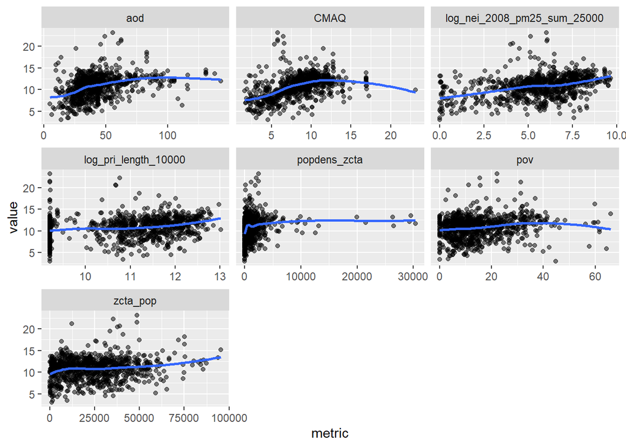

```r
#Plots the relationship between our predictors and PM2.5 concentration
dat0 |>
  select(value, CMAQ, aod, zcta_pop, log_pri_length_10000, log_nei_2008_pm25_sum_25000, popdens_zcta, pov) |>
  pivot_longer(-value, names_to = "name", values_to = "metric") |>
  ggplot(aes(metric, value)) +
  geom_point(alpha = 1/2) +
  geom_smooth(se = FALSE) +
  facet_wrap(vars(name), scales = 'free_x')
```

Overall, there seems to be an overall slightly positive relationship between the different variables and air pollution. The population density however is harder to tell as there is funneling in the data.

Let’s also check to correlations between our chosen predictors and PM2.5 concentration

```r
# Calculates the correlations between PM2.5 and our different predictor variables
cor(dat0$CMAQ, dat0$value)
```

```
## [1] 0.4661511
```

```r
cor(dat0$aod, dat0$value)
```

```
## [1] 0.3498192
```

```r
cor(dat0$log_nei_2008_pm25_sum_25000, dat0$value)
```

```
## [1] 0.377129
```

```r
cor(dat0$log_pri_length_10000, dat0$value)
```

```
## [1] 0.2178476
```

```r
cor(dat0$popdens_zcta, dat0$value)
```

```
## [1] 0.133054
```

```r
cor(dat0$pov, dat0$value)
```

```
## [1] 0.163784
```

```r
cor(dat0$zcta_pop, dat0$value)
```

```
## [1] 0.1563638
```

Overall, the correlations for all of our predictor variables are relatively low with the highest correlation being from CMAQ.

Based on the scatter plots and correlation values, I expect the RMSE performance of our models to be relatively high. Maybe around 2.

## Wrangling

The data that is already loaded is already tidy so I will just do some minor changes I want to remove the clutter from the variables that I would not use and remove rows with NA values.

```r
# Selects our variables and remove any potential NA values
dat <- dat0|>
  select(value, CMAQ, aod, zcta_pop, log_pri_length_10000, log_nei_2008_pm25_sum_25000, popdens_zcta, pov)|>
  na.omit()
```

No rows were removed from the na.omit() function. We are now ready to fit our models for linear regression, k-nearest neighbor, and random forest.

## Results

Let’s first split our data between training and testing

```r
# Sets seed so potential randomized actions can be repeated
set.seed(322)

# Splits data into training and testing data
dat_split <- initial_split(dat)
# Gets the training data
dat_train <- training(dat_split)
```

Let’s first fit a linear regression model

```r
# Create recipe for our model and normalizes variables
rec <- dat_train|>
  recipe(value ~ CMAQ + aod + zcta_pop + log_pri_length_10000 +
           log_nei_2008_pm25_sum_25000 + popdens_zcta + pov) |>
  step_normalize(-value)

# Sets linear regression model
model <- linear_reg()|>
  set_engine('lm')|>
  set_mode('regression')

wf <- workflow()|>
  add_recipe(rec)|>
  add_model(model)

# Cross validation using 10 folds
folds <- vfold_cv(dat_train, v = 10)

res <- fit_resamples(wf, resamples = folds,
                     metrics = metric_set(rmse))
res|>
  collect_metrics()
```

| .metric | .estimator | mean | n | std_err | .config |
| --- | --- | --- | --- | --- | --- |
| rmse | standard | 2.063235 | 10 | 0.0749512 | Preprocessor1_Model1 |

The root mean squared error is 2.063 for our linear regression model which is close to what I have initially predicted

Let’s save this into a table

```r
# Creates empty 3x2 table
table <- matrix(nrow = 3, ncol = 2, byrow = T)
# Adds column and row names
colnames(table) <- c('RMSE', 'Std Error')
rownames(table) <- c('Linear Regression', 'K-nearest neighbors', 'Random Forest')
# Fills in values I collected
table[1,1] <- 2.063235
table[1,2] <- 0.0749512
table
```

```
##                         RMSE Std Error
## Linear Regression   2.063235 0.0749512
## K-nearest neighbors       NA        NA
## Random Forest             NA        NA
```

Let’s move onto K-nearest neighbors. I am going to use the same recipe but the model will now use nearest_neighbor instead. I am also going to tune the neighbors parameter.

```r
# Model uses K-nn and will tune the neighbors parameter
model <- nearest_neighbor(neighbors = tune("k")) |>
  set_engine("kknn") |>
  set_mode("regression")

wf <- workflow()|>
  add_recipe(rec)|>
  add_model(model)

# Cross validation using 10 folds
folds <- vfold_cv(dat_train, v = 10)

res <- tune_grid(wf, resamples = folds,
                 grid = tibble(k = seq(10, 40, 1)),
                 metrics = metric_set(rmse))

# Finds which number of neighbors will result in the lowest RMSE value
res|>
  collect_metrics()|>
  arrange(mean)
```

| k | .metric | .estimator | mean | n | std_err | .config |
| --- | --- | --- | --- | --- | --- | --- |
| 31 | rmse | standard | 1.954341 | 10 | 0.06093155 | Preprocessor1_Model22 |
| 30 | rmse | standard | 1.954413 | 10 | 0.06131507 | Preprocessor1_Model21 |
| 32 | rmse | standard | 1.954439 | 10 | 0.06060809 | Preprocessor1_Model23 |
| 33 | rmse | standard | 1.954518 | 10 | 0.06035538 | Preprocessor1_Model24 |
| 29 | rmse | standard | 1.954663 | 10 | 0.06174586 | Preprocessor1_Model20 |
| 34 | rmse | standard | 1.954664 | 10 | 0.06012248 | Preprocessor1_Model25 |
| 35 | rmse | standard | 1.954823 | 10 | 0.05990935 | Preprocessor1_Model26 |
| 28 | rmse | standard | 1.954940 | 10 | 0.06214148 | Preprocessor1_Model19 |
| 36 | rmse | standard | 1.954962 | 10 | 0.05970156 | Preprocessor1_Model27 |
| 37 | rmse | standard | 1.955240 | 10 | 0.05951804 | Preprocessor1_Model28 |

[output cut: 21 more lines]

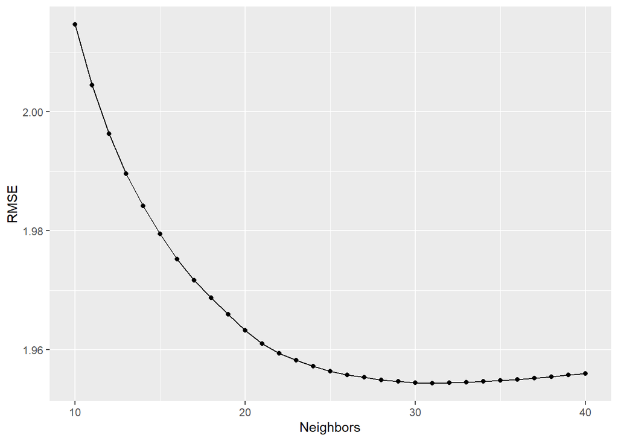

```r
# Plots RMSE values across k values
res|>
  collect_metrics()|>
  ggplot(aes(x = k, y = mean))+
  labs(x = 'Neighbors', y = 'RMSE')+
  geom_point() +
  geom_line()
```

The K-nearest neighbor model yielded a lower RMSE value than the linear regression model when k is set at 31. While the RMSE value is lower, it is still close to 2.